# A Tarot Story

# Intro

Hey its me! The card shark in your soul…. and what I have is even **MORE DATA !!**. So much of it in fact I could make tarot accessible to everybody!

But one a more serious note, this visual data story aims to interpret data about Tarot Cards! Using some *data science* techniques we will be able to weave story about this project.

The cards shark in your soul… (TM), reminds you that all data collected will be used responsibly and not be sold on foreign data markets.

Fore more information vist: What the Card?!

## Logic’s in the Air?

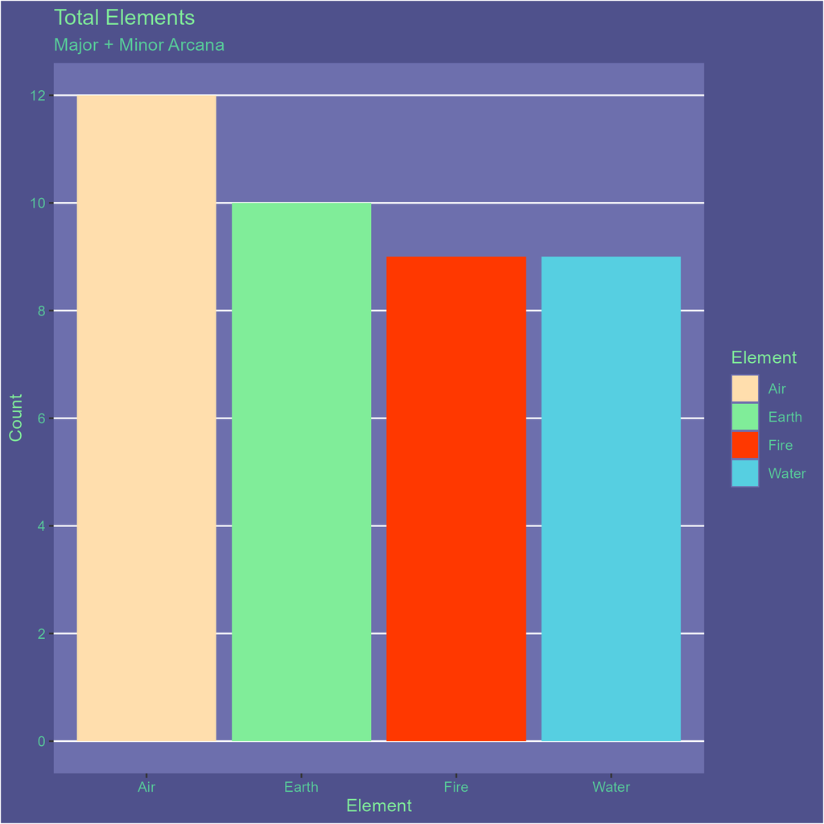

The Predominant element for this project was **Air**! Air is associated with logic, thought and communication. A very strange coincidence considering that this project requires logic in your R coding, communication if you choose to do it in a group and thought to plan the whole thing out.

## A mouthful of words.

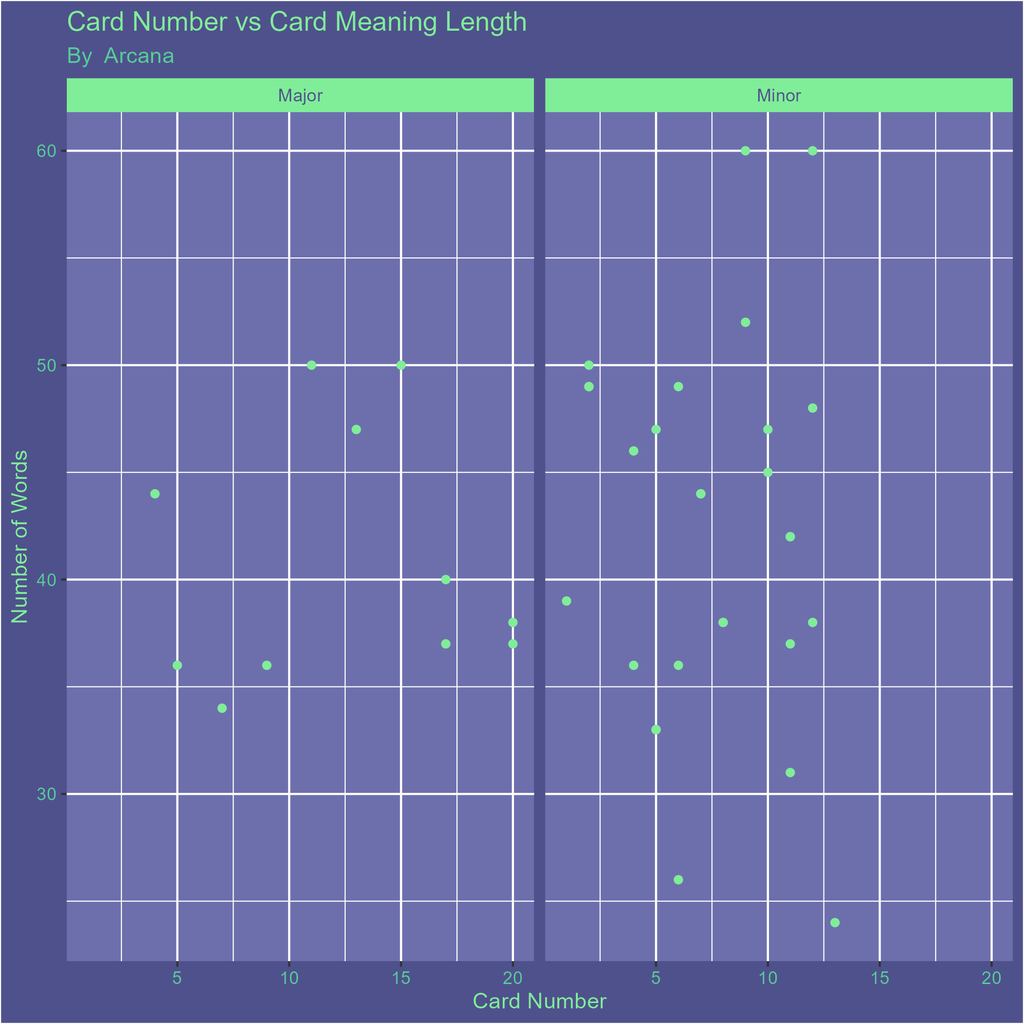

The card shark in your soul… (TM) is proud to present, variation!

The graph above represents the the word count of a specific card (number in this case) split across the Arcana.

Once interesting about this graph (other than no apparent correlation between the variables) is the variation. Tarot is open to the interpretation of who ever is reading the cards and we see that in the above graph.

For some of the observations that are doubled the have different word counts. Now in the case of the minor arcana this could be due to the different suit.

## Time Flies!

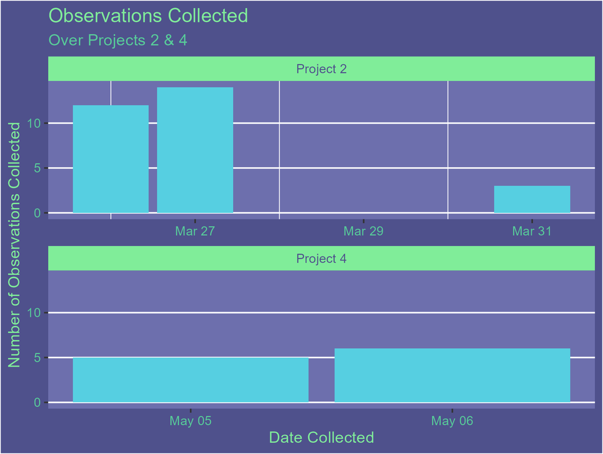

Finally the most powerful tool in the card shark in your soul… (TM), the passage of **TIME**!

The above graph show case how many observations that me and my partner gathered of over the course of the two projects.

Surprise, surprise its just 40 if you sum it all up. But its nice to visualise the passing of 2/3 projects. As you can see the bulk of our observations come from project 2. We collected 29 observations during that period.

Most of them were collected on the 26th & 27th of March, with a few more being collected on the 31st. we were then able to make up the difference for project 4, only taking us two days to collect.

(Shout out to the marker who added one!)

Tarot much like time flows, the story it tell you is ever changing. But take some *time* to reflect, I’m sure you’ll find it worth it!